# TM01_trump_tweets

# 1 Libraries

- `tidyverse` is a collection of several useful packages.
- `tidytext` implements tidy data principles to make many text mining tasks easier, more effective (Using `browseVignettes(package = "tidytext")` to get more information)
- `tidytext` package imeplements the following functions including …
  - `get_sentiments()` to get a tidy data_frame of a single sentiemnt lexicon.
  - `cast_tdm()` to cast a data frame to a DocumentTermMatrix.
  - `unnest_tokens()` to tokenized sentence or text to words.
  - `bind_tf_idf()` to create tf and idf variables

```r
library(tidyverse)
library(stringr)
library(tidytext)
```

- Setting global options firstly to ensure that character varaibles won’t be converted to factor varaible.

```r
options(stringsAsFactors = FALSE)
```

# 2 Loading data

- 2015-06-16 to elect
- 2016-05-03 in-party
- 2016-09-16 1st debate
- 2016-11-08 2016 election

### 2.0.1 varianeexplained’s data

## 2.1 trump’s data over 2016 election

```r
# load("data/alltweets.RData")
raw.df <- readRDS("data/alltweets.rds")
raw.df %>% summary()
```

```
    source             id_str              text            created_at
 Length:30749       Length:30749       Length:30749       Length:30749
 Class :character   Class :character   Class :character   Class :character
 Mode  :character   Mode  :character   Mode  :character   Mode  :character



 retweet_count    in_reply_to_user_id_str favorite_count   is_retweet
 Min.   :     0   Length:30749            Min.   :     0   Mode :logical
 1st Qu.:    15   Class :character        1st Qu.:    20   FALSE:30534
 Median :    79   Mode  :character        Median :    60   TRUE :215
 Mean   :  1535                           Mean   :  4171
 3rd Qu.:   736                           3rd Qu.:  1007
 Max.   :344806                           Max.   :633253
   timestamp
 Min.   :2009-05-05 02:54:25
 1st Qu.:2013-04-26 00:50:55
 Median :2014-07-08 18:50:51
 Mean   :2014-06-20 07:36:58
 3rd Qu.:2015-07-24 20:38:07
 Max.   :2017-04-12 04:27:35
```

```r
filtered.df <- raw.df %>%
    filter(!str_detect(text, '^"')) %>%
    filter(timestamp > as.POSIXct("2014-12-01") &
               timestamp < as.POSIXct("2017-05-08"))
```

# 3 Doc-Level analysis

- **Doc properites**
  - Number of document over time.
  - nchar distribution to confirm the property of docs compared with other social media.
- **User study** to confirm (whether) who are involved most in the data.
  - Posting frequency
  - Posting activity over time

## 3.1 Number of tweets over time

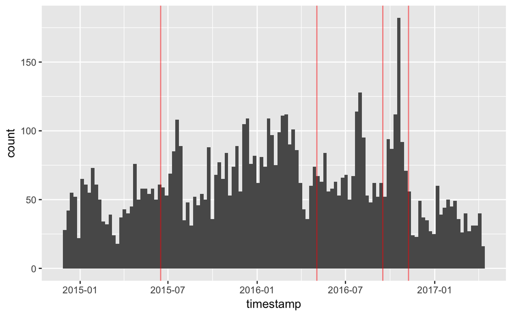

```r
filtered.df %>%
    ggplot(aes(timestamp)) +
    geom_histogram(bins=120) +
    geom_vline(xintercept = as.numeric(as.POSIXct(c("2015-06-16", "2016-05-03",
                                                    "2016-09-16", "2016-11-08"))),
             color="red", alpha=0.5)
```

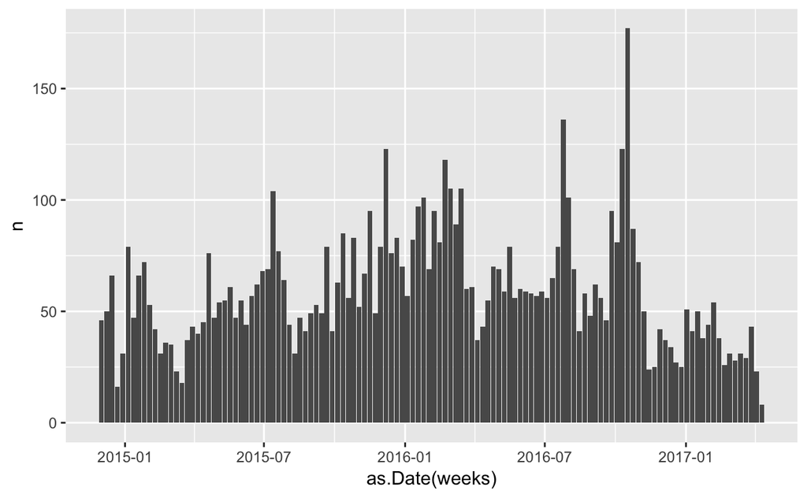

```r
filtered.df %>%
    mutate(weeks = cut(timestamp, breaks="week")) %>%
    count(weeks) %>%
    ggplot(aes(as.Date(weeks), n)) +
    geom_col()
```

## 3.2 by hour

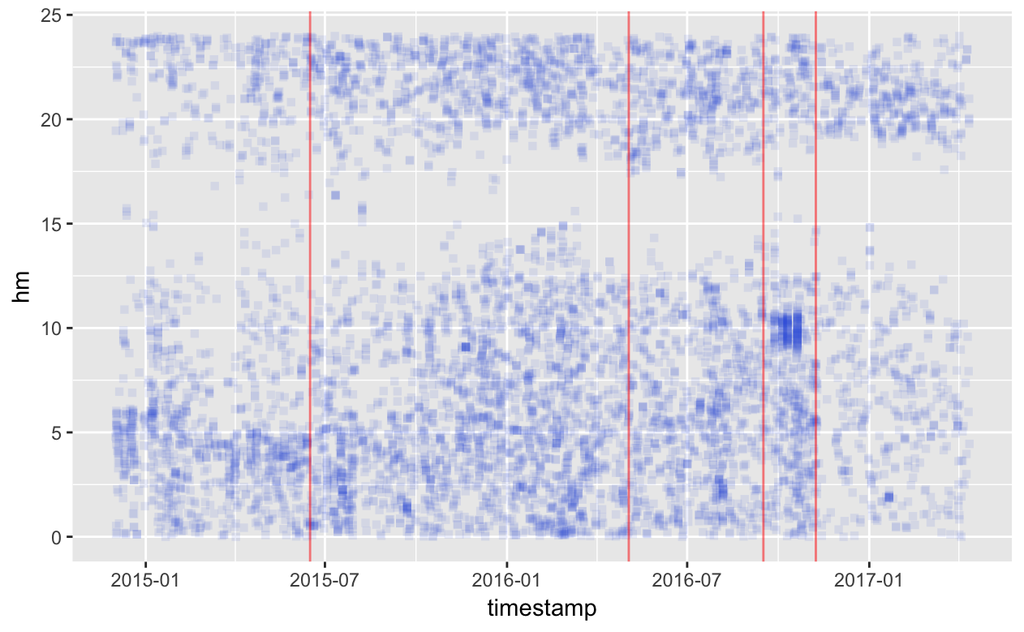

```r
library(lubridate)
filtered.df %>%
    mutate(hm = hour(timestamp) + minute(timestamp)/60) %>%
    ggplot(aes(timestamp, hm)) +
    geom_point(color = "royalblue", alpha = 0.1, shape = 15) +
    geom_vline(xintercept = as.numeric(as.POSIXct(c("2015-06-16", "2016-05-03",
                                                    "2016-09-16", "2016-11-08"))),
             color="red", alpha=0.5)
```

## 3.3 nchar distribution

> … We want every person around the world to easily express themselves on Twitter, so we’re doing something new: we’re going to try out a longer limit, 280 characters, in languages impacted by cramming (which is all except Japanese, Chinese, and Korean). https://github.com/adam-p/markdown-here/wiki/Markdown-Cheatsheet

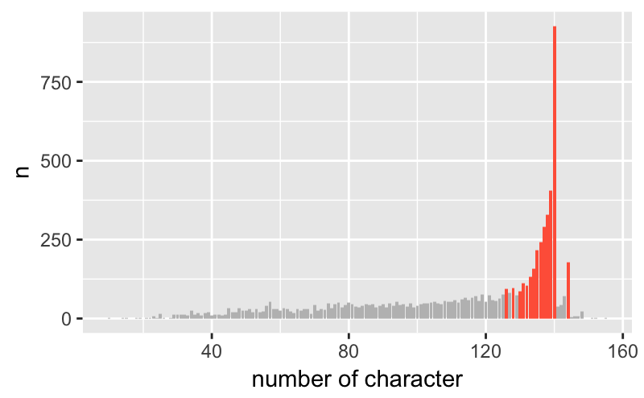

```r
filtered.df %>%
    mutate(nchar = nchar(text)) %>%
    # select(text, nchar, everything()) %>%
    count(nchar) %>%
    mutate(highfreq=ifelse(n > quantile(n, 0.9),
                           "high", "other")) %>%
    ggplot(aes(nchar, n, fill = highfreq)) +
    geom_col() +
    xlab("number of character") +
    scale_fill_manual(values=c("high"="tomato",
                               "other"="gray"), guide=F)
```

# 4 Word level analysis

## 4.1 unnest text to word

```r
data(stop_words)
unnested.df <- filtered.df %>%
    mutate(text = str_replace_all(text,
                                  "https://t.co/[A-Za-z\\d]+|&amp;", "")) %>%
    # unnest_tokens(word, text, drop = FALSE) %>%
    unnest_tokens(word, text,
                  token = "regex", pattern = "[^A-Za-z\\d#@']",
                  drop=FALSE)
# %>%
#     anti_join(stop_words)
```

## 4.2 hot words

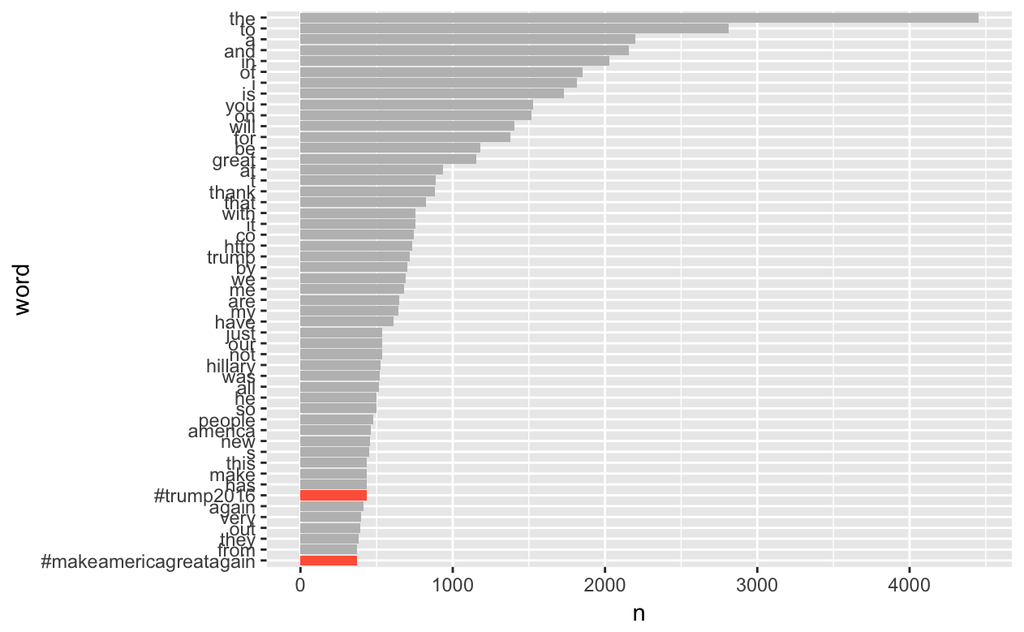

```r
unnested.df %>%
    count(word) %>%
    mutate(word = reorder(word, n)) %>%
    top_n(50, wt = n) %>%
    mutate(ismedia = ifelse(str_detect(word, "@.*|#.*"),
                            "tag",
                            "other")) %>%
    ggplot(aes(word, n, fill=ismedia)) +
    geom_col() +
    coord_flip() +
    scale_fill_manual(values = c("tag" = "tomato",
                                 "other" = "gray"),
                      guide = F)
```

```r
NA
```

## 4.3 freuqnecy of word

- The distribution follows an `power law distribution` (very few words occur very often, very many words occur very rare). The `Zipf law` says that the frequency of a word is reciprocal to its `rank (1 / r)`. To make the plot more readable, the axes can be logarithmized.

```r
unnested.df %>%
    count(word) %>%
    count(n) %>%
    ggplot(aes(n, nn)) +
    geom_point(color = "royalblue", alpha=0.5) +
    ggtitle("Word frequency distribution") +
    xlab("word frequency") + ylab("Distribution") +
    # theme(plot.title = element_text(hjust = 0.5)) +
    scale_x_log10() +
    scale_y_log10()
```

[output not shown]

## 4.4 n-words per tweets

- Does the trump often use fewer words that other politician?

```r
unnested.df %>%
    count(id_str) %>%
    ggplot(aes(n))  +
    geom_histogram()
```

[output not shown]

## 4.5 Time series of selected words

```r
watched <- c("my", "our", "great", "you", "your", "I", "me")
unnested.df %>%
    filter(word %in% watched) %>%
    mutate(weeks = cut(timestamp, breaks="month")) %>%
    count(weeks, word) %>%
    group_by(weeks) %>%
    mutate(perc = n/sum(n))%>%
    ungroup() %>%
    ggplot(aes(as.POSIXct(weeks), perc, color = word)) +
    geom_line() +
    geom_vline(xintercept = as.numeric(as.POSIXct(c("2015-06-16", "2016-05-03",
                                                    "2016-09-16", "2016-11-08"))),
             color="red", alpha=0.5)
```

[output not shown]

## 4.6 wordcloud

- Mentioned in 陳世榮（2015）. Bock對於目前相當流行的文字雲（word cloud）批評指出， 文字雲並不具備科學或推論意義，它僅是基於「文字頻率代表某種意義」的假設下，提供 了讀者一種無限制的解讀（Bock, 2009） 。

  ```
  pal_r <- brewer.pal(9, "PuRd")[-(1:2)]
  wordcloud(words = y2016$word, freq = y2016$logratio, min.freq = 1,
  random.order = F, colors = pal_g, max.words = 100, rot.per = 0)
  ```

```r
library(wordcloud)

pal_g <- brewer.pal(9, "BuGn")[-(1:2)]


unnested.df %>%
    count(word) %>%
    with(wordcloud(word, n, max.words = 100,
                   random.order = F,
                   colors = brewer.pal(9, "BuGn")[-(1:2)],
                   rot.per = 0))
```

[output not shown]

## 4.7 tf-idf

```r
tf_idf <- unnested.df %>%
    anti_join(stop_words) %>%
    filter(!str_detect(word, "\\d")) %>%
    count(text, word, sort = T) %>%
    bind_tf_idf(word, text, n)

tf_idf %>%
    ggplot(aes(tf_idf)) +
    geom_histogram(bins=100) +
    scale_x_log10()
```

[output not shown]

```r
library(janeaustenr)

book_words <- austen_books() %>%
    unnest_tokens(word, text) %>%
    count(book, word, sort = TRUE) %>%
    ungroup() %>%
    bind_tf_idf(word, book, n)

book_words %>%
    ggplot(aes(tf_idf)) +
    geom_histogram(bins = 100) +
    scale_x_log10()
```

[output not shown]